# Peer Assessment II

# 1 Background

As a statistical consultant working for a real estate investment firm, your task is to develop a model to predict the selling price of a given home in Ames, Iowa. Your employer hopes to use this information to help assess whether the asking price of a house is higher or lower than the true value of the house. If the home is undervalued, it may be a good investment for the firm.

# 2 Training Data and relevant packages

In order to better assess the quality of the model you will produce, the data have been randomly divided into three separate pieces: a training data set, a testing data set, and a validation data set. For now we will load the training data set, the others will be loaded and used later.

```r
load("ames_train")
load("ames_test")
load("ames_validation")
```

```r
library(ggplot2)
library(statsr)
library(dplyr)
library(BAS)
library(GGally)
library(gridExtra)
library(MASS)
```

## 2.1 Part 1 - Exploratory Data Analysis (EDA)

When you first get your data, it’s very tempting to immediately begin fitting models and assessing how they perform. However, before you begin modeling, it’s absolutely essential to explore the structure of the data and the relationships between the variables in the data set.

I have completed EDA of the ames_train data set, to learn about the structure of the data and the relationships between the variables in the data set. Below 3 plots I found most informative during EDA process.

The mantra in real estate is “Location, Location, Location!”. The median is preferred in this summary statistic due to high variability and outliers.

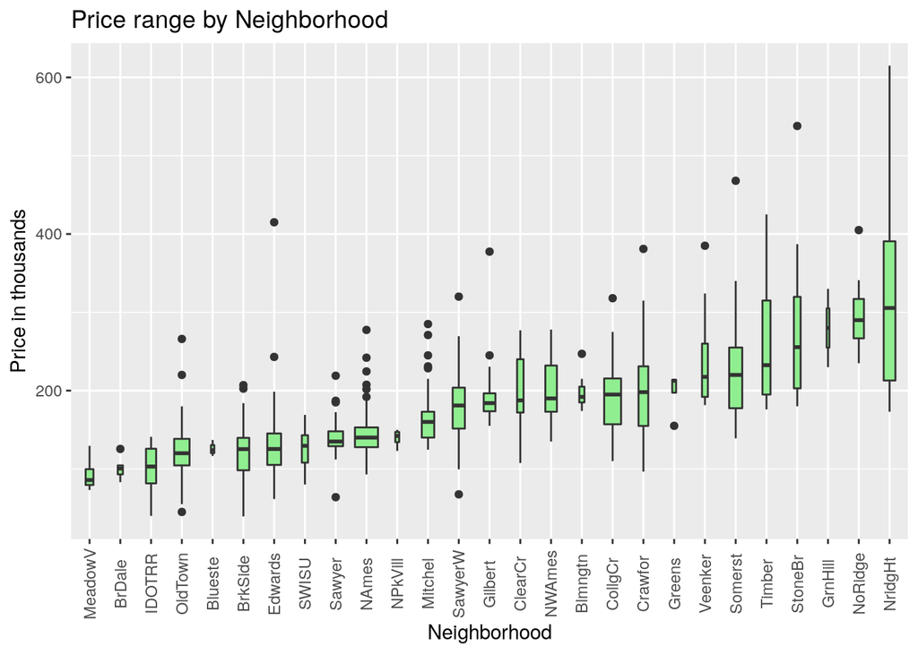

```r
ggplot(data = ames_train, aes(x = reorder(Neighborhood, price, FUN=median), y = price/1000, group = Neighborhood)) +
  geom_boxplot(fill="lightgreen", varwidth = TRUE)  +
  labs(y = "Price in thousands", x = "Neighborhood", title = "Price range by Neighborhood")   +
  theme(axis.text.x = element_text(angle = 90, vjust = 0.5, hjust=0.5))
```

```r
ames_location <-ames_train%>%
  dplyr::select(price, Year.Built, Neighborhood) %>%
  group_by(Neighborhood)%>%
  summarise(max = max(price), min = min(price), median = median(price), sd = sd(price), year = median(Year.Built))

arrange(ames_location, desc(median, sd))  %>% head()
```

```
## # A tibble: 6 x 6
##   Neighborhood    max    min median      sd  year
##   <fct>         <dbl>  <dbl>  <dbl>   <dbl> <dbl>
## 1 NridgHt      615000 173000 305500 105806.  2005
## 2 NoRidge      405000 235000 290000  35889.  1994
## 3 GrnHill      330000 230000 280000  70711.  1992
## 4 StoneBr      538000 180000 255500 104622.  2000
## 5 Timber       425000 176000 232500  82153.  2002
## 6 Somerst      468000 139000 220000  62416.  2004
```

MeadowV($85,750) and BrDale($100,500) are in opposite having the lowest median price with much older houses in the area.

```r
arrange(ames_location, median) %>% head()
```

```
## # A tibble: 6 x 6
##   Neighborhood    max    min median     sd  year
##   <fct>         <dbl>  <dbl>  <dbl>  <dbl> <dbl>
## 1 MeadowV      129500  73000  85750 18940.  1971
## 2 BrDale       125500  83000 100500 13596.  1972
## 3 IDOTRR       141000  40000 103000 26438.  1927
## 4 OldTown      265979  45000 120000 34944.  1920
## 5 Blueste      137000 116500 123900 10381.  1980
## 6 BrkSide      207000  39300 125250 38466.  1928
```

The overall material and finish of the house is usually higher for the newer houses, thus the price is positively correlated.

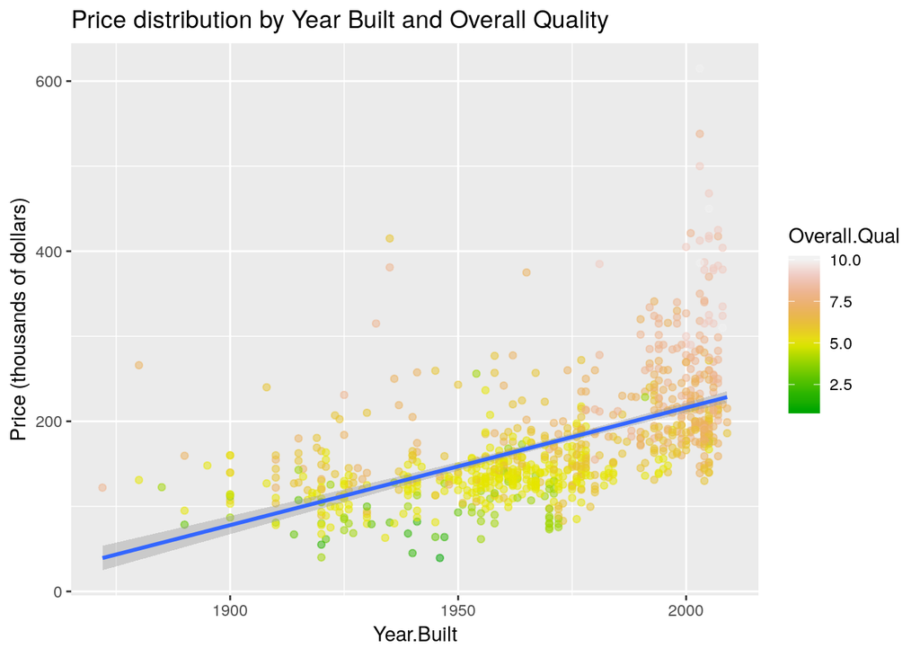

```r
ggplot(data = ames_train, aes(y = price/1000, x = Year.Built, color =  Overall.Qual)) +
  geom_point(alpha = 0.5) +
  stat_smooth( method = "lm") +
  scale_colour_gradientn(colours = terrain.colors(10)) +
  ggtitle("Price distribution by Year Built and Overall Quality") +
  ylab("Price (thousands of dollars)")
```

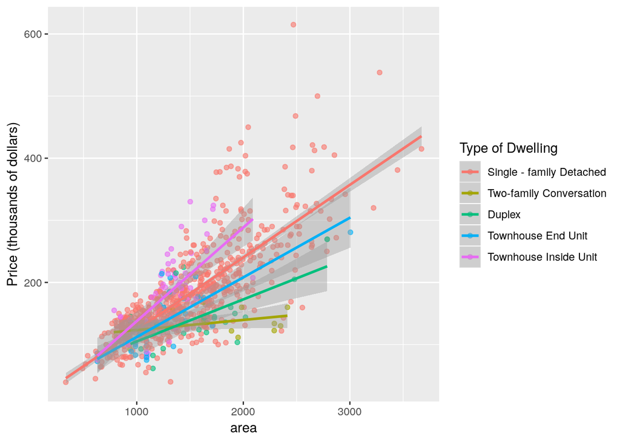

```r
ggplot(data = ames_train, aes(x = area, y = price/1000, color = Bldg.Type)) +
  geom_point(alpha = 0.6) +
  stat_smooth( method = "lm") +
  scale_colour_discrete(
                       name="Type of Dwelling",
                       breaks=c("1Fam", "2fmCon","Duplex", "Twnhs", "TwnhsE"),
                       labels=c("Single - family Detached","Two-family Conversation","Duplex", "Townhouse End Unit", "Townhouse Inside Unit")) +
   ylab("Price (thousands of dollars)")
```

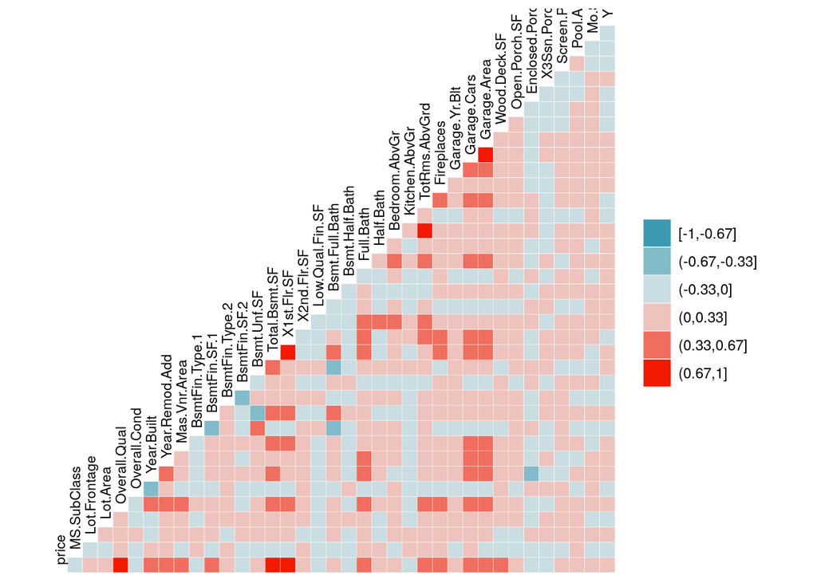

```r
ggcorr(ames_train[,c(2,3:78)], size = 3, ,  angle = 90, hjust = 0, nbreaks = 6)
```

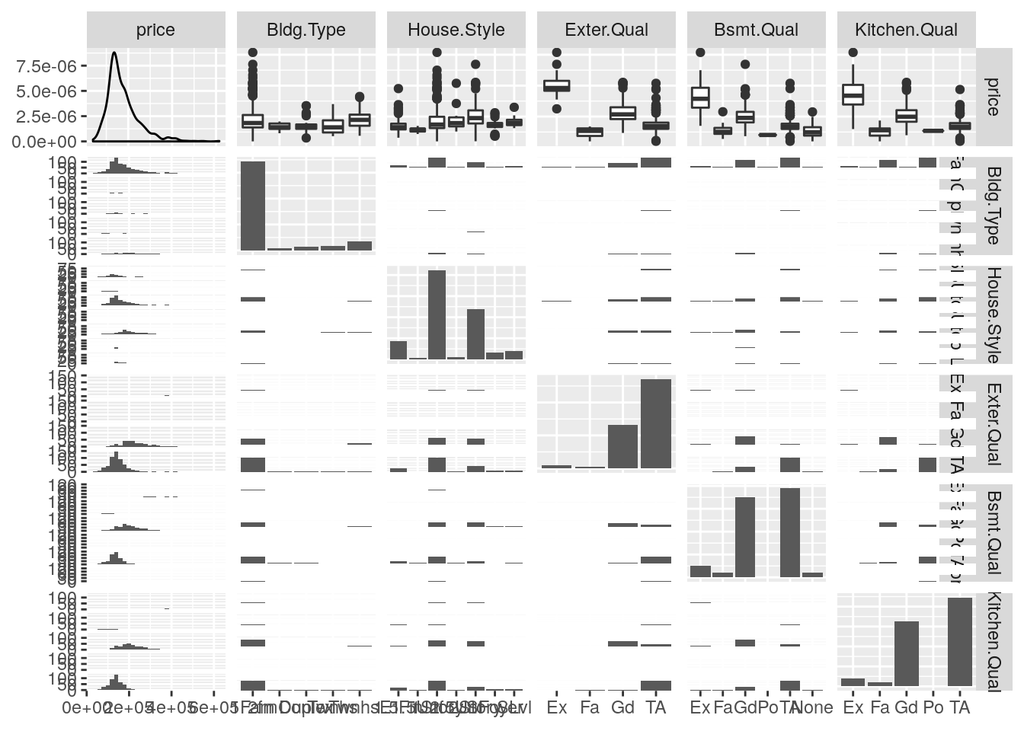

```r
ggpairs(ames_train[,c(2, 17, 18, 29, 32, 54)])
```

* * *

## 2.2 Part 2 - Development and assessment of an initial model, following a semi-guided process of analysis

### 2.2.1 Section 2.1 An Initial Model

In building a model, it is often useful to start by creating a simple, intuitive initial model based on the results of the exploratory data analysis.

Based on EDA, I selected following variables for the initial model:

[output not shown]

The logarithmic transformation will be used for the price and Lot.Area variables due to their skewness. By using the logarithm of variable, we obtain a more normally distributed variable that is more suitable for liniar regression modeling. The area variable is right skewed as well, but the model performs better without log(area).

```r
# Lograrithmic transformation
ames_train <- ames_train %>%
  mutate(log_price=log(price), log_area = log(area), log_lotarea = log(Lot.Area))

df.initial.model <- dplyr::select(ames_train,
                                  log_price,
                                  log_lotarea,
                                  area,
                                  Neighborhood,
                                  Overall.Qual,
                                  Year.Built,
                                  Bldg.Type,
                                  TotRms.AbvGrd,
                                  Garage.Cars,
                                  Full.Bath,
                                  Bsmt.Full.Bath)

initial.model <- lm(log_price ~ . - log_price,data = df.initial.model)

summary(initial.model)
```

```
##
## Call:
## lm(formula = log_price ~ . - log_price, data = df.initial.model)
##
## Residuals:
##      Min       1Q   Median       3Q      Max
## -0.86756 -0.06053  0.00163  0.07447  0.37552
##
## Coefficients:
##                       Estimate Std. Error t value Pr(>|t|)
## (Intercept)          4.014e+00  7.152e-01   5.613 2.75e-08 ***
## log_lotarea          9.573e-02  1.385e-02   6.911 9.88e-12 ***
## area                 3.092e-04  1.934e-05  15.983  < 2e-16 ***
## NeighborhoodBlueste -6.712e-02  8.565e-02  -0.784 0.433421
## NeighborhoodBrDale  -1.763e-01  6.995e-02  -2.521 0.011902 *
## NeighborhoodBrkSide -7.900e-02  5.841e-02  -1.352 0.176630
## NeighborhoodClearCr -2.288e-02  6.461e-02  -0.354 0.723371
## NeighborhoodCollgCr -1.043e-01  5.221e-02  -1.997 0.046140 *
## NeighborhoodCrawfor  4.249e-02  5.844e-02   0.727 0.467383
## NeighborhoodEdwards -1.465e-01  5.471e-02  -2.677 0.007571 **
## NeighborhoodGilbert -1.411e-01  5.426e-02  -2.601 0.009477 **
## NeighborhoodGreens   2.662e-02  7.734e-02   0.344 0.730819
## NeighborhoodGrnHill  3.383e-01  9.769e-02   3.463 0.000563 ***
## NeighborhoodIDOTRR  -1.817e-01  6.010e-02  -3.023 0.002583 **
## NeighborhoodMeadowV -1.623e-01  5.837e-02  -2.780 0.005571 **
## NeighborhoodMitchel -7.492e-02  5.427e-02  -1.380 0.167870
## NeighborhoodNAmes   -6.043e-02  5.359e-02  -1.128 0.259818
## NeighborhoodNoRidge -8.030e-02  5.547e-02  -1.448 0.148124
## NeighborhoodNPkVill -2.598e-02  7.855e-02  -0.331 0.740941
## NeighborhoodNridgHt  1.560e-02  5.248e-02   0.297 0.766387
## NeighborhoodNWAmes  -1.117e-01  5.455e-02  -2.047 0.040954 *
## NeighborhoodOldTown -1.165e-01  5.822e-02  -2.001 0.045684 *
## NeighborhoodSawyer  -9.030e-02  5.484e-02  -1.647 0.100007
## NeighborhoodSawyerW -1.575e-01  5.329e-02  -2.955 0.003215 **
## NeighborhoodSomerst -3.205e-02  5.081e-02  -0.631 0.528352
## NeighborhoodStoneBr -2.966e-02  5.839e-02  -0.508 0.611612
## NeighborhoodSWISU   -1.493e-01  6.686e-02  -2.233 0.025814 *
## NeighborhoodTimber  -3.932e-02  5.849e-02  -0.672 0.501634
## NeighborhoodVeenker -1.106e-02  6.448e-02  -0.172 0.863844
## Overall.Qual         9.292e-02  5.434e-03  17.100  < 2e-16 ***
## Year.Built           3.114e-03  3.503e-04   8.891  < 2e-16 ***
## Bldg.Type2fmCon     -5.164e-02  3.070e-02  -1.682 0.092931 .
## Bldg.TypeDuplex     -1.521e-01  2.645e-02  -5.751 1.27e-08 ***
## Bldg.TypeTwnhs      -7.639e-02  3.394e-02  -2.251 0.024673 *
## Bldg.TypeTwnhsE     -3.497e-02  2.363e-02  -1.480 0.139177
## TotRms.AbvGrd       -4.043e-03  5.343e-03  -0.757 0.449456
## Garage.Cars          3.841e-02  8.312e-03   4.621 4.46e-06 ***
## Full.Bath           -7.394e-03  1.295e-02  -0.571 0.568294
## Bsmt.Full.Bath       8.698e-02  8.929e-03   9.741  < 2e-16 ***
## ---
## Signif. codes:  0 '***' 0.001 '**' 0.01 '*' 0.05 '.' 0.1 ' ' 1
##
## Residual standard error: 0.1192 on 795 degrees of freedom
## Multiple R-squared:  0.907,  Adjusted R-squared:  0.9026
## F-statistic: 204.1 on 38 and 795 DF,  p-value: < 2.2e-16
```

This model does a pretty good job of prediction with an R-squared value of 0.907. R-squared is a statistical measure of how close the data are to the fitted regression line. R-squared closure to indicates that the model explains the variability of the response data around its mean.

### 2.2.2 Section 2.2 Model Selection

In this section I will use stepwise selection procedure to choose the “best” model based on initial model. I will use AIC and BIC methods and compare results. Additionally, I will use `BAS` R package and Bayesian model averaging (BMA), which involves averaging over many possible models. BMA can be used for prediction, averaging predictions from multiple models according to their posterior probabilities.

```r
initial.model.BIC <- bas.lm(
                    log_price ~
                    log_lotarea +
                    area +
                    Neighborhood +
                    Overall.Qual +
                    Year.Built +
                    Bldg.Type +
                    TotRms.AbvGrd +
                    Garage.Cars +
                    Bsmt.Full.Bath +
                    Full.Bath
                    ,data = ames_train, prior = "BIC", modelprior=uniform())
predict.train.initial.model.BIC <- predict(initial.model.BIC, newdata = ames_train, estimator="BMA")

ames_train <- ames_train %>% mutate(
  res.log_price = log_price - predict.train.initial.model.BIC$fit,
  predicted.price = price / exp(res.log_price),
  residual = price - predicted.price,
  predicted.log.price = predict.train.initial.model.BIC$fit
)

r2 = 1 - sum(ames_train$res.log_price^2)/sum((ames_train$log_price-mean(ames_train$log_price))^2)
r2
```

```
## [1] 0.8892251
```

$$BIC: \ R^2 = 0.8892$$

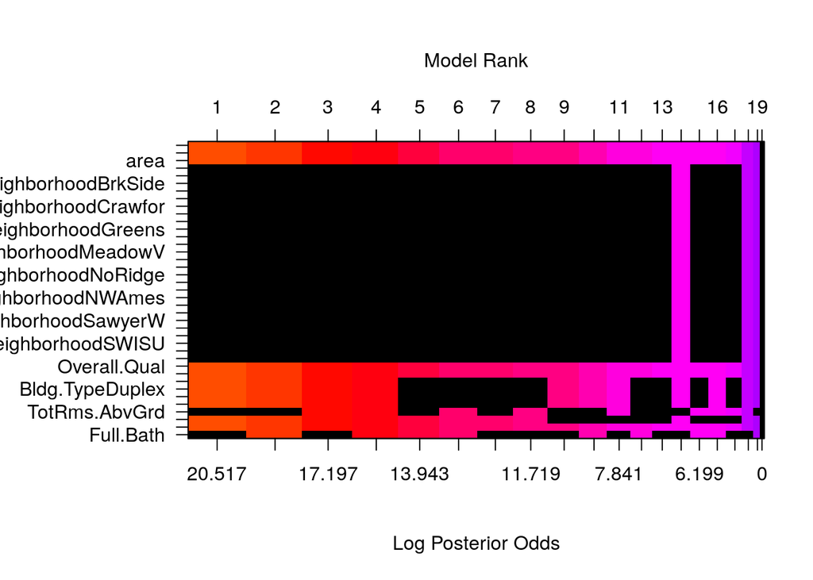

```r
image(initial.model.BIC, rotate = F)
```

```r
initial.model.AIC <- bas.lm(
                    log_price ~
                    log_lotarea +
                    area +
                    Neighborhood +
                    Overall.Qual +
                    Year.Built +
                    Bldg.Type +
                    TotRms.AbvGrd +
                    Garage.Cars +
                    Bsmt.Full.Bath +
                    Full.Bath
                    ,data = ames_train, prior = "AIC", modelprior=uniform())
predict.train.initial.model.AIC <- predict(initial.model.AIC, newdata = ames_train, estimator="BMA")

ames_train <- ames_train %>% mutate(
  res.log_price = log_price - predict.train.initial.model.AIC$fit,
  predicted.price = price / exp(res.log_price),
  residual = price - predicted.price,
  predicted.log.price = predict.train.initial.model.AIC$fit
)

r2 = 1 - sum(ames_train$res.log_price^2)/sum((ames_train$log_price-mean(ames_train$log_price))^2)
r2
```

```
## [1] 0.906966
```

```r
round(summary(initial.model.AIC),2)
```

```
##                     P(B != 0 | Y)  model 1  model 2  model 3  model 4
## Intercept                    1.00     1.00     1.00     1.00     1.00
## log_lotarea                  1.00     1.00     1.00     1.00     1.00
## area                         1.00     1.00     1.00     1.00     1.00
## NeighborhoodBlueste          1.00     1.00     1.00     1.00     1.00
## NeighborhoodBrDale           1.00     1.00     1.00     1.00     1.00
## NeighborhoodBrkSide          1.00     1.00     1.00     1.00     1.00
## NeighborhoodClearCr          1.00     1.00     1.00     1.00     1.00
## NeighborhoodCollgCr          1.00     1.00     1.00     1.00     1.00
## NeighborhoodCrawfor          1.00     1.00     1.00     1.00     1.00
## NeighborhoodEdwards          1.00     1.00     1.00     1.00     1.00
## NeighborhoodGilbert          1.00     1.00     1.00     1.00     1.00
## NeighborhoodGreens           1.00     1.00     1.00     1.00     1.00
## NeighborhoodGrnHill          1.00     1.00     1.00     1.00     1.00
## NeighborhoodIDOTRR           1.00     1.00     1.00     1.00     1.00
## NeighborhoodMeadowV          1.00     1.00     1.00     1.00     1.00
## NeighborhoodMitchel          1.00     1.00     1.00     1.00     1.00
## NeighborhoodNAmes            1.00     1.00     1.00     1.00     1.00
## NeighborhoodNoRidge          1.00     1.00     1.00     1.00     1.00
## NeighborhoodNPkVill          1.00     1.00     1.00     1.00     1.00
## NeighborhoodNridgHt          1.00     1.00     1.00     1.00     1.00
## NeighborhoodNWAmes           1.00     1.00     1.00     1.00     1.00
## NeighborhoodOldTown          1.00     1.00     1.00     1.00     1.00
## NeighborhoodSawyer           1.00     1.00     1.00     1.00     1.00
## NeighborhoodSawyerW          1.00     1.00     1.00     1.00     1.00
## NeighborhoodSomerst          1.00     1.00     1.00     1.00     1.00
## NeighborhoodStoneBr          1.00     1.00     1.00     1.00     1.00
## NeighborhoodSWISU            1.00     1.00     1.00     1.00     1.00
## NeighborhoodTimber           1.00     1.00     1.00     1.00     1.00
## NeighborhoodVeenker          1.00     1.00     1.00     1.00     1.00
## Overall.Qual                 1.00     1.00     1.00     1.00     1.00
## Year.Built                   1.00     1.00     1.00     1.00     1.00
## Bldg.Type2fmCon              1.00     1.00     1.00     1.00     1.00
## Bldg.TypeDuplex              1.00     1.00     1.00     1.00     1.00
## Bldg.TypeTwnhs               1.00     1.00     1.00     1.00     1.00
## Bldg.TypeTwnhsE              1.00     1.00     1.00     1.00     1.00
## TotRms.AbvGrd                0.34     0.00     1.00     0.00     1.00
## Garage.Cars                  1.00     1.00     1.00     1.00     1.00
## Bsmt.Full.Bath               1.00     1.00     1.00     1.00     1.00
## Full.Bath                    0.31     0.00     0.00     1.00     1.00
```

[output cut: 35 more lines]

```
## Overall.Qual            1.00
## Year.Built              1.00
## Bldg.Type2fmCon         1.00
## Bldg.TypeDuplex         1.00
## Bldg.TypeTwnhs          1.00
## Bldg.TypeTwnhsE         1.00
## TotRms.AbvGrd           0.00
## Garage.Cars             0.00
## Bsmt.Full.Bath          1.00
## Full.Bath               0.00
## BF                      0.00
## PostProbs               0.00
## R2                      0.90
## dim                    36.00
## logmarg             -1058.76
```

$$AIC: \ R^2 = 0.9069$$

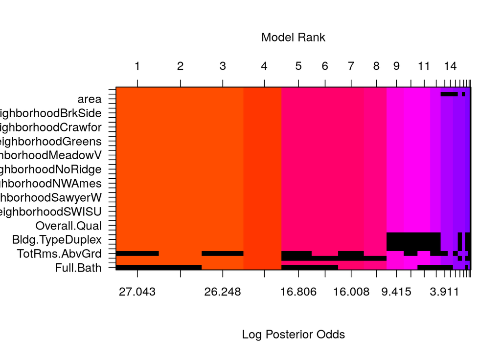

```r
image(initial.model.AIC, rotate = F)
```

The AIC model has higher Adjusted R-squared 0.907 compare to BIC model with Adjusted R-squared 0.8892.

BIC model has lesser predictor variables resulting in more parsimonious model which is great for interpretation. But BIC is best for explanation as it is allows consistent estimation of the underlying data generating process.

The model using AIC as criteria using more predictor varibales which is better to maximize predictive discrimination.

As the main purpose of the assessment is predicting the price, I will chose the AIC model as it fulfills objective better.

### 2.2.3 Section 2.3 Initial Model Residuals

One way to assess the performance of a model is to examine the model’s residuals.

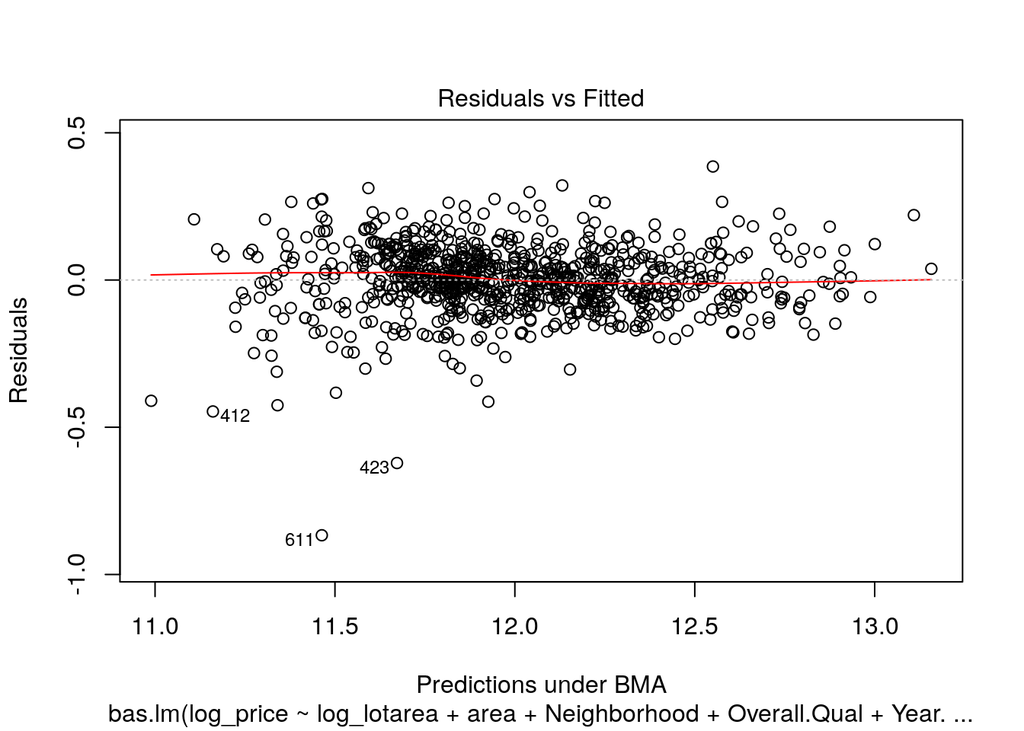

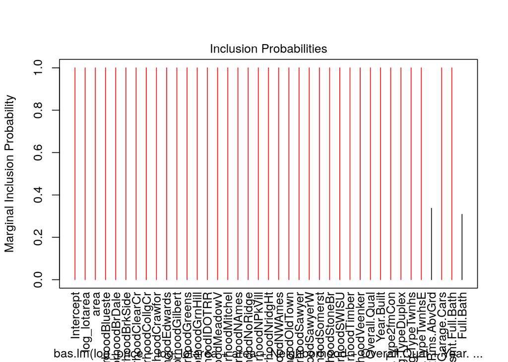

```r
plot(initial.model.AIC, which = c(1,4) )
```

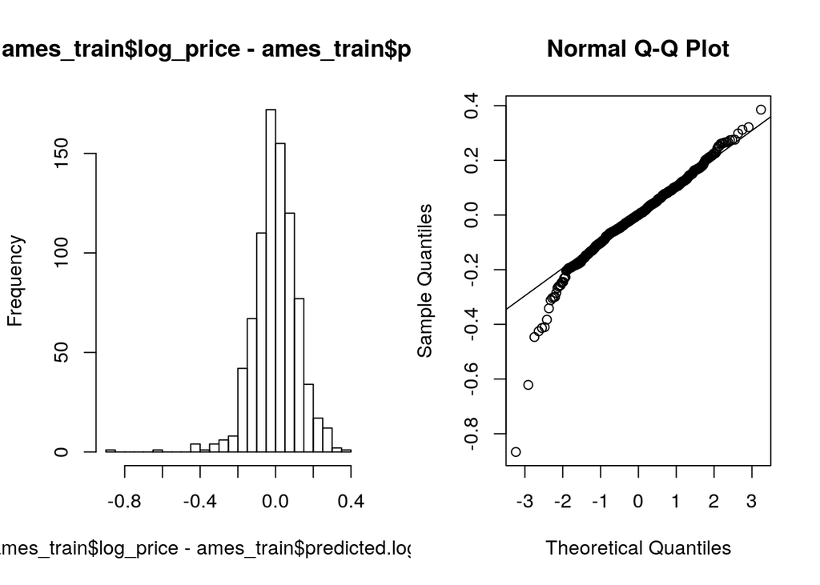

```r
layout(matrix(c(1,2), 1, 2, byrow = TRUE))
hist(ames_train$log_price - ames_train$predicted.log.price, breaks = 30)
qqnorm(ames_train$log_price - ames_train$predicted.log.price)
qqline(ames_train$log_price - ames_train$predicted.log.price)
```

The model has few outliers:

- 611 is a Commercial property. Having only 5 comercial properties in the data set, we have not enough observations, and therefore the price is overpredicted.
- 423 has garage in Poor quality, the variable Garage.Qual will be included in the final model.

Other than heavy tails on the normal distribution of the residuals (the difference between the observed value and the predicted value), there does not appear to exist any major assumption violation in the residuals plot. As the sample number is quite large, it should not be a problem.

### 2.2.4 Section 2.4 Initial Model RMSE

In general, the better the model fits, the lower RMSE. The residuals from the initial model exhibit a standard deviation, and RMSE is $20,143.

```r
ames.train.initial.rmse <- sqrt(mean((ames_train$residual)^2))
ames.train.initial.rmse
```

```
## [1] 20143.01
```

### 2.2.5 Section 2.5 Overfitting

We next test the initial model with out-of-sample data. This will give indication if the model perform well or not (“overfitting”).

```r
ames_test <- ames_test %>%
  filter(Neighborhood != 'Landmrk')

ames_test <- ames_test %>%
  mutate(log_price=log(price), log_area = log(area), log_lotarea = log(Lot.Area))

initial.test.model.AIC <- predict(initial.model.AIC, newdata = ames_test, estimator="BMA")

ames_test <- ames_test %>% mutate(
  res.log_price = log_price - initial.test.model.AIC$fit,
  predicted.price = price / exp(res.log_price),
  residual = price - predicted.price,
  predicted.log.price = initial.test.model.AIC$fit
)

r2 = 1 - sum(ames_test$res.log_price^2)/sum((ames_test$log_price-mean(ames_test$log_price))^2)
r2
```

```
## [1] 0.8950198
```

```r
ames.test.initial.rmse <- sqrt(mean((ames_test$residual)^2))
ames.test.initial.rmse
```

```
## [1] 21211.57
```

Residuals distribution is very similar to the initial model.

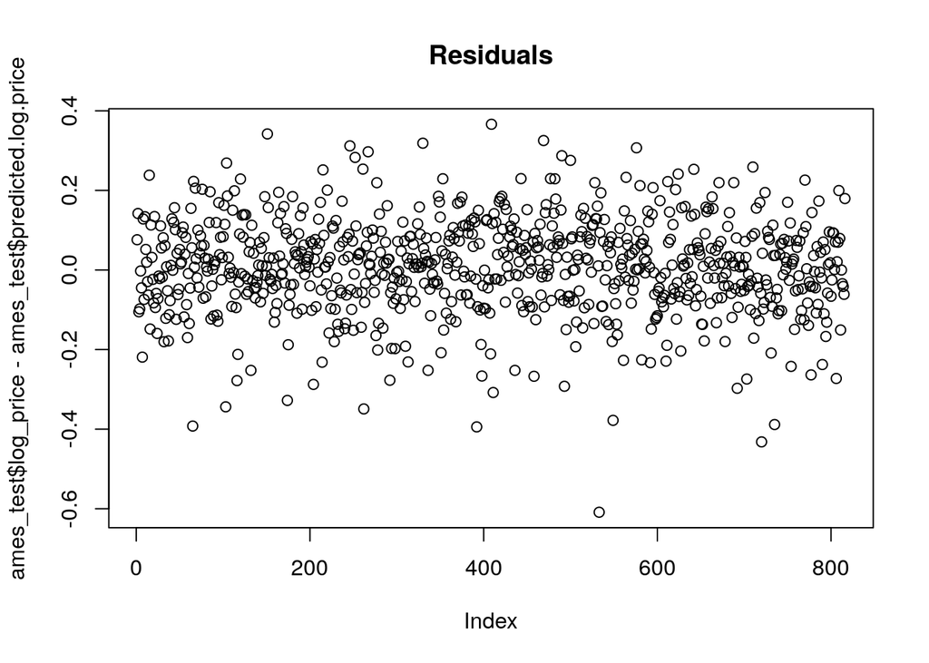

```r
plot(ames_test$log_price - ames_test$predicted.log.price, main = 'Residuals')
```

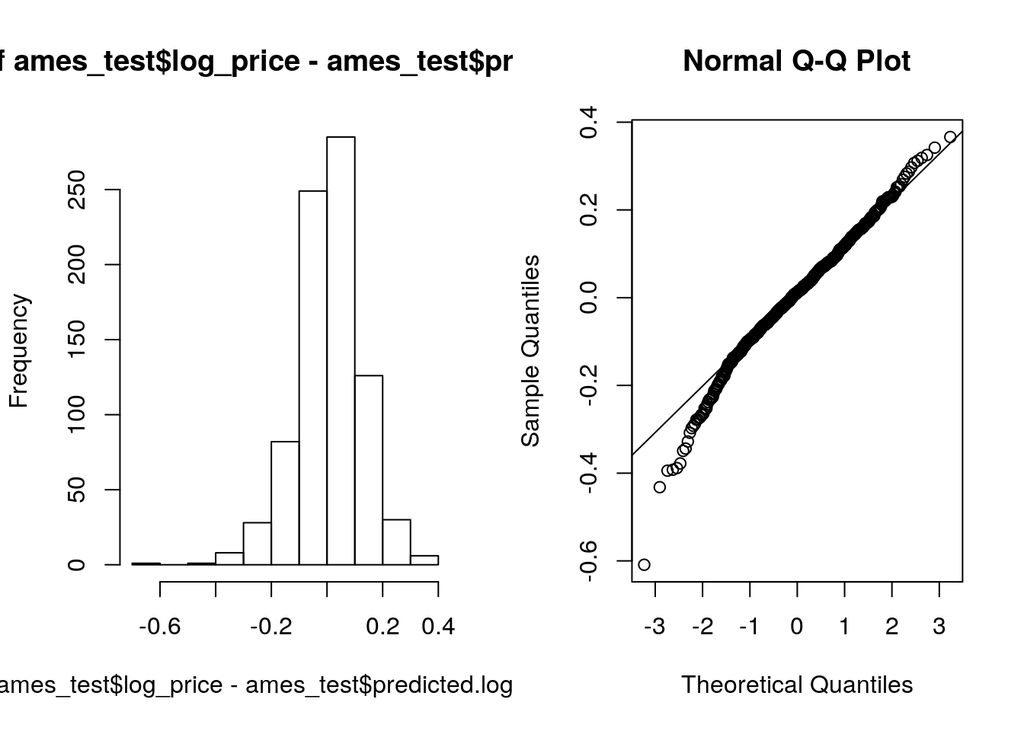

```r
layout(matrix(c(1,2), 1, 2, byrow = TRUE))
hist(ames_test$log_price - ames_test$predicted.log.price, breaks = 10)
qqnorm(ames_test$log_price - ames_test$predicted.log.price)
qqline(ames_test$log_price - ames_test$predicted.log.price)
```

## 2.3 Part 3 Development of a Final Model

### 2.3.1 Section 3.1 Final Model

There is not much trouble with outliers, which were discussed in the initial model testing.

```r
final.model.AIC <- bas.lm(log_price ~
                   log_lotarea +
                   area +
                   Neighborhood +
                   Overall.Qual +
                   Exter.Qual+
                   Year.Built +
                   Bldg.Type  +
                   TotRms.AbvGrd +
                   Overall.Cond +
                   Garage.Cars +
                   Full.Bath +
                   Bsmt.Full.Bath +
                   Kitchen.Qual +
                   Total.Bsmt.SF +
                   Garage.Qual,
                   data = ames_train,
                   prior = "AIC", modelprior=uniform())
```

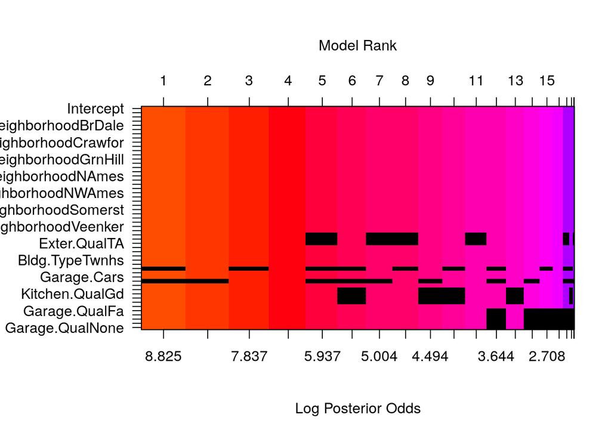

```r
image(final.model.AIC, rotate = F)
```

```r
round(summary(final.model.AIC),2)
```

```
##                     P(B != 0 | Y) model 1 model 2 model 3 model 4 model 5
## Intercept                    1.00    1.00    1.00    1.00    1.00    1.00
## log_lotarea                  1.00    1.00    1.00    1.00    1.00    1.00
## area                         1.00    1.00    1.00    1.00    1.00    1.00
## NeighborhoodBlueste          1.00    1.00    1.00    1.00    1.00    1.00
## NeighborhoodBrDale           1.00    1.00    1.00    1.00    1.00    1.00
## NeighborhoodBrkSide          1.00    1.00    1.00    1.00    1.00    1.00
## NeighborhoodClearCr          1.00    1.00    1.00    1.00    1.00    1.00
## NeighborhoodCollgCr          1.00    1.00    1.00    1.00    1.00    1.00
## NeighborhoodCrawfor          1.00    1.00    1.00    1.00    1.00    1.00
## NeighborhoodEdwards          1.00    1.00    1.00    1.00    1.00    1.00
## NeighborhoodGilbert          1.00    1.00    1.00    1.00    1.00    1.00
## NeighborhoodGreens           1.00    1.00    1.00    1.00    1.00    1.00
## NeighborhoodGrnHill          1.00    1.00    1.00    1.00    1.00    1.00
## NeighborhoodIDOTRR           1.00    1.00    1.00    1.00    1.00    1.00
## NeighborhoodMeadowV          1.00    1.00    1.00    1.00    1.00    1.00
## NeighborhoodMitchel          1.00    1.00    1.00    1.00    1.00    1.00
## NeighborhoodNAmes            1.00    1.00    1.00    1.00    1.00    1.00
## NeighborhoodNoRidge          1.00    1.00    1.00    1.00    1.00    1.00
## NeighborhoodNPkVill          1.00    1.00    1.00    1.00    1.00    1.00
## NeighborhoodNridgHt          1.00    1.00    1.00    1.00    1.00    1.00
## NeighborhoodNWAmes           1.00    1.00    1.00    1.00    1.00    1.00
## NeighborhoodOldTown          1.00    1.00    1.00    1.00    1.00    1.00
## NeighborhoodSawyer           1.00    1.00    1.00    1.00    1.00    1.00
## NeighborhoodSawyerW          1.00    1.00    1.00    1.00    1.00    1.00
## NeighborhoodSomerst          1.00    1.00    1.00    1.00    1.00    1.00
## NeighborhoodStoneBr          1.00    1.00    1.00    1.00    1.00    1.00
## NeighborhoodSWISU            1.00    1.00    1.00    1.00    1.00    1.00
## NeighborhoodTimber           1.00    1.00    1.00    1.00    1.00    1.00
## NeighborhoodVeenker          1.00    1.00    1.00    1.00    1.00    1.00
## Overall.Qual                 1.00    1.00    1.00    1.00    1.00    1.00
## Exter.QualFa                 0.95    1.00    1.00    1.00    1.00    0.00
## Exter.QualGd                 0.95    1.00    1.00    1.00    1.00    0.00
## Exter.QualTA                 0.95    1.00    1.00    1.00    1.00    0.00
## Year.Built                   1.00    1.00    1.00    1.00    1.00    1.00
## Bldg.Type2fmCon              1.00    1.00    1.00    1.00    1.00    1.00
## Bldg.TypeDuplex              1.00    1.00    1.00    1.00    1.00    1.00
## Bldg.TypeTwnhs               1.00    1.00    1.00    1.00    1.00    1.00
## Bldg.TypeTwnhsE              1.00    1.00    1.00    1.00    1.00    1.00
## TotRms.AbvGrd                0.30    0.00    1.00    0.00    1.00    0.00
## Overall.Cond                 1.00    1.00    1.00    1.00    1.00    1.00
## Garage.Cars                  1.00    1.00    1.00    1.00    1.00    1.00
## Full.Bath                    0.27    0.00    0.00    1.00    1.00    0.00
## Bsmt.Full.Bath               1.00    1.00    1.00    1.00    1.00    1.00
## Kitchen.QualFa               0.97    1.00    1.00    1.00    1.00    1.00
## Kitchen.QualGd               0.97    1.00    1.00    1.00    1.00    1.00
## Kitchen.QualPo               0.97    1.00    1.00    1.00    1.00    1.00
## Kitchen.QualTA               0.97    1.00    1.00    1.00    1.00    1.00
## Total.Bsmt.SF                1.00    1.00    1.00    1.00    1.00    1.00
## Garage.QualFa                0.99    1.00    1.00    1.00    1.00    1.00
## Garage.QualGd                0.99    1.00    1.00    1.00    1.00    1.00
## Garage.QualPo                0.99    1.00    1.00    1.00    1.00    1.00
## Garage.QualTA                0.99    1.00    1.00    1.00    1.00    1.00
## Garage.QualNone              0.99    1.00    1.00    1.00    1.00    1.00
## BF                             NA    1.00    0.42    0.37    0.16    0.06
## PostProbs                      NA    0.47    0.20    0.17    0.07    0.03
## R2                             NA    0.94    0.94    0.94    0.94    0.94
## dim                            NA   51.00   52.00   52.00   53.00   48.00
## logmarg                        NA -868.12 -868.97 -869.11 -869.97 -871.01
```

```r
predict.train.final.model.AIC <- predict(final.model.AIC, newdata = ames_train, estimator="BMA")

ames_train <- ames_train %>% mutate(
  res.log_price = log_price - predict.train.final.model.AIC$fit,
  predicted.price = price / exp(res.log_price),
  residual = price - predicted.price,
  predicted.log.price = predict.train.final.model.AIC$fit)

r2 = 1 - sum(ames_train$res.log_price^2)/sum((ames_train$log_price-mean(ames_train$log_price))^2)
r2
```

```
## [1] 0.9415994
```

```r
ames_train_rmse <- sqrt(mean((ames_train$residual)^2))
ames_train_rmse
```

```
## [1] 16187.84
```

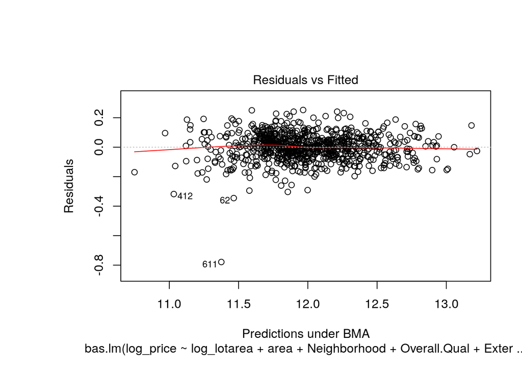

```r
plot(final.model.AIC, which = 1 )
```

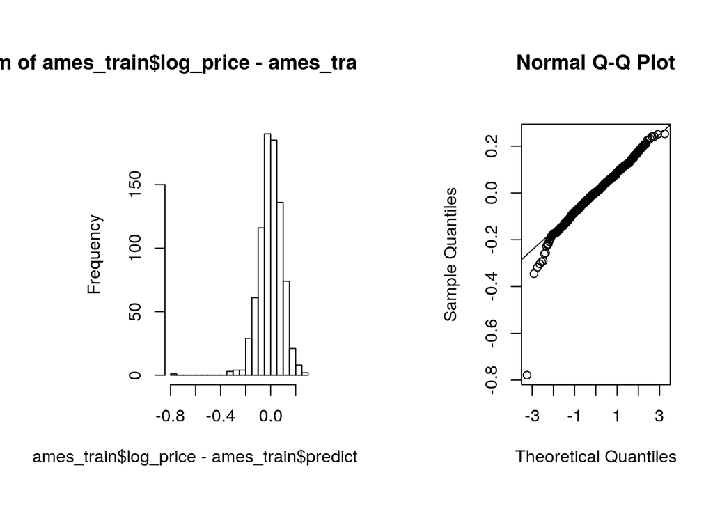

```r
layout(matrix(c(1,2), 1, 2, byrow = TRUE))
hist(ames_train$log_price - ames_train$predicted.log.price, breaks = 30)
qqnorm(ames_train$log_price - ames_train$predicted.log.price)
qqline(ames_train$log_price - ames_train$predicted.log.price)
```

### 2.3.2 Section 3.2 Transformation

As mentioned in the Section 2.1 the following variables were log-transformed: price and Lot.Area. The reason for doing it is that all of them are right skewed. It was mentioned that the area variable performs bit better than log(area).

Misc.Feature, Misc.Val, PID cannot be generalized to be used as a meaningful variable, so they were supressed.

Variables with missing value were replaced to None or 0 value according to variable type.

As houses with non-normal selling condition exhibit atypical behavior and can disproportionately influence the model, the model was built for only normal sale condition.

### 2.3.3 Section 3.3 Variable Interaction

Interaction effects occur when the effect of one variable depends on the value of another variable. Interaction effects are common in regression analysis, ANOVA, and designed experiments. Variable interactions were not included in the model.

### 2.3.4 Section 3.4 Variable Selection

Home price is determined by its location, its size, its age and its quality. As location variable, I choose Neighborhood. As size variables, I included area, log(Lot.Area), Basement square feet “Total.Bsmt.SF”“. As age variable I included”Year.Built“. As quality variables, I included “Overall.Qual”, “Overall.Cond”, “Kitchen.Qual”,”Garage.Qual“, “Exter.Qual”,”Full.Bath" and “Bsmt.Full.Bath”.

I used the backward elimination BIC and AIC methods. AIC model performed better, while BIC was having more parsimonious model. As the main purpose of the project is predicting the price, I chose the AIC model as it fulfills objective better. Additionally, Bayesian model averaging (BMA) is utilised for averaging over many possible models.

Some variables are not included due to remote relationship to the price, some other variables are not included due to the collinearity with variables which are included in this model. For example, Garage.Cars and Garage.Area are correlated, so only Garage.Cars was used in the model.

### 2.3.5 Section 3.5 Model Testing

How did testing the model on out-of-sample data affect whether or how you changed your model? Explain in a few sentences.

The model achieves $R^2$ = 0.9268 with RMSE of $17,842. Compared to results in training, that is a 1.4% decrease in $R^2$ and a $1,655 increase in RMSE. These differences are reasonable, and yield a successful test of our model on out-of-sample data.

```r
final.test.model.AIC <- predict(final.model.AIC, newdata = ames_test, estimator="BMA")

ames_test <- ames_test %>% mutate(
  res.log_price = log_price - final.test.model.AIC$fit,
  predicted.price = price / exp(res.log_price),
  residual = price - predicted.price,
  predicted.log.price = final.test.model.AIC$fit
)

r2 = 1 - sum(ames_test$res.log_price^2)/sum((ames_test$log_price-mean(ames_test$log_price))^2)
r2
```

```
## [1] 0.9268533
```

```r
ames.test.final.rmse <- sqrt(mean((ames_test$residual)^2))
ames.test.final.rmse
```

```
## [1] 17842.33
```

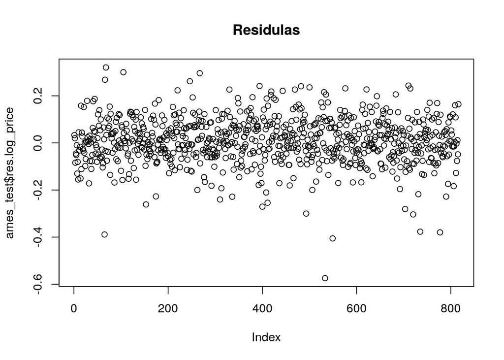

```r
plot(ames_test$res.log_price, main= 'Residulas')
```

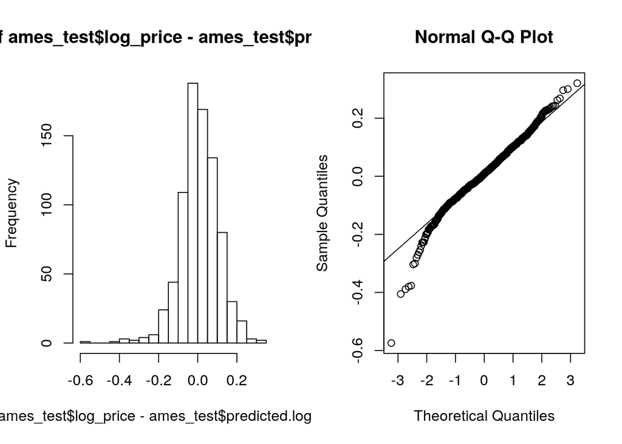

```r
layout(matrix(c(1,2), 1, 2, byrow = TRUE))
hist(ames_test$log_price - ames_test$predicted.log.price, breaks = 30)
qqnorm(ames_test$log_price - ames_test$predicted.log.price)
qqline(ames_test$log_price - ames_test$predicted.log.price)
```

## 2.4 Part 4 Final Model Assessment

### 2.4.1 Section 4.1 Final Model Evaluation

Overall, the model might be considered quite successful in terms of ability to usefully explain the variation in sale price ($R^2$ = 0.94) and only 6% of the variation in price remained unexplained by this model.

Notable weaknesses are the following:

- A small but seemingly significant number of houses sell for much less than predicted.
- The model cannot predict prices in one neighborhood Landmrk which was absent from the training data.
- The model can be used for residential property only.
- The model could be used for propery with the area below 36,000 sq.ft and Lot.Area 215,000 sq.ft.
- Being trained with data from the Great Recession, the model has a very unrealistic assumption that prices never increase with time.

### 2.4.2 Section 4.2 Final Model Validation

Finally we check the model a separate, validation data set, which hasn’t been used for testing until now. The results are very similar to those with ames_test, and again the difference with ames_train is reasonable.

ames_train: $R^2$ = 0.94, RMSE = $16,187

ames_test: $R^2$ = 0.9268 ,RMSE = $17,842

ames_validation: $R^2$ = 0.9212, RMSE = $18,270

```r
ames_validation <- ames_validation %>%
  mutate(log_price=log(price), log_area = log(area), log_lotarea = log(Lot.Area))

predict.validation.final.model.AIC <- predict(final.model.AIC, newdata = ames_validation, estimator="BMA")
ames_validation <- ames_validation %>% mutate(
  res.log_price = log_price - predict.validation.final.model.AIC$fit,
  predicted.price = price / exp(res.log_price),
  residual = price - predicted.price,
  predicted.log.price = predict.validation.final.model.AIC$fit
)

r2 = 1 - sum(ames_validation$res.log_price^2)/sum((ames_validation$log_price-mean(ames_validation$log_price))^2)
r2
```

```
## [1] 0.9211845
```

```r
ames_validationt_rmse <- sqrt(mean((ames_validation$residual)^2))
ames_validationt_rmse
```

```
## [1] 18270.5
```

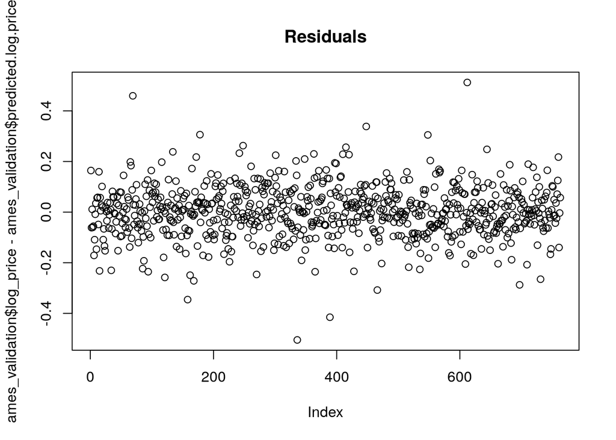

```r
plot(ames_validation$log_price - ames_validation$predicted.log.price, main = 'Residuals')
```

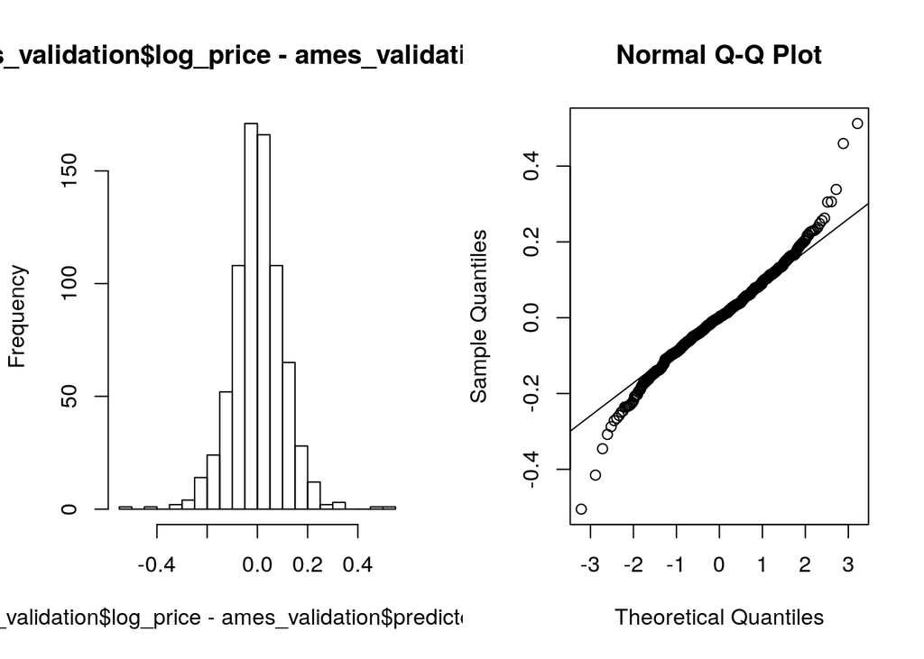

```r
layout(matrix(c(1,2), 1, 2, byrow = TRUE))
hist(ames_validation$log_price - ames_validation$predicted.log.price, breaks = 30)
qqnorm(ames_validation$log_price - ames_validation$predicted.log.price)
qqline(ames_validation$log_price - ames_validation$predicted.log.price)
```

There are very heavy tails, indicating a problem with a small but significant number of large-magnitude residuals (both positive and negative).

```r
predict.validation <- predict(final.model.AIC, ames_validation,  estimator="BMA",
                              prediction=TRUE, se.fit=TRUE)
predict.df = as.data.frame(cbind(confint(predict.validation), price = ames_validation$log_price))
# Fix names in dataset
colnames(predict.df)[1:2] <- c("lwr", "upr")

# Get Coverage
coverage.prob.validation <- predict.df %>% summarize(cover = sum(price >= lwr & price <= upr)/n())
coverage.prob.validation
```

```
##       cover
## 1 0.9423329
```

```r
ames_validation <- ames_validation%>%
        mutate(valuation =ifelse(residual < 0, "Over-Valued", "Under-Valued"))

idx <- which(predict.df$price < predict.df$lwr | predict.df$price > predict.df$upr)

ames_validation[idx, c("PID", "price", "area", "Lot.Area", "Neighborhood", "predicted.price", "residual", "valuation") ]
```

```
## # A tibble: 44 x 8
##       PID  price  area Lot.Area Neighborhood predicted.price residual
##     <int>  <int> <int>    <int> <fct>                  <dbl>    <dbl>
##  1 9.10e8  55000   796     3636 IDOTRR                69373.  -14373.
##  2 9.08e8 130000  1709     2522 Edwards              163629.  -33629.
##  3 5.35e8  93500  1040     8544 NAmes                 76683.   16817.
##  4 9.05e8 216000  1325    17541 Edwards              136413.   79587.
##  5 9.09e8 170000  1680    17871 Crawfor              212540.  -42540.
##  6 9.02e8  87000  1774     9600 OldTown              105450.  -18450.
##  7 9.03e8  97500  1864     5852 OldTown              123389.  -25889.
##  8 9.03e8 205000  1548     7264 BrkSide              168256.   36744.
##  9 9.03e8  84500   754     6780 IDOTRR               109375.  -24875.
## 10 5.35e8 163000  1040    11500 NAmes                128461.   34539.
## # … with 34 more rows, and 1 more variable: valuation <chr>
```

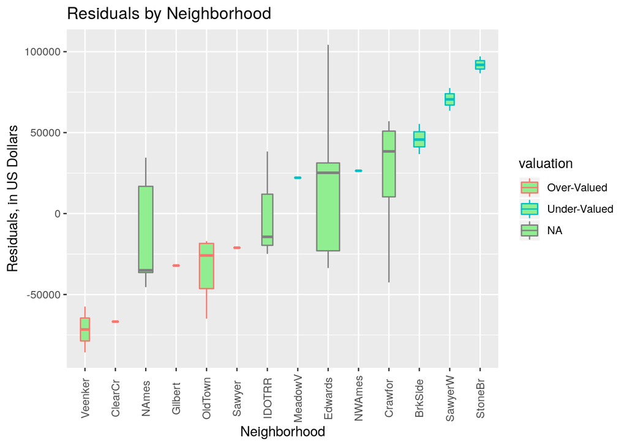

```r
ggplot(data = ames_validation[idx,], aes(x = reorder(Neighborhood, residual, FUN=median), y = residual, group = Neighborhood, color = valuation)) +
  geom_boxplot(fill="lightgreen", varwidth = TRUE)  +
  labs(y = "Residuals, in US Dollars", x = "Neighborhood", title = "Residuals by Neighborhood")   +
  theme(axis.text.x = element_text(angle = 90, vjust = 0.5, hjust=0.5))
```

The scatter plot below shows which homes are estimated to be over-valued and under-valued. The summary shows that about half of the houses are over-valued and the other half are under-valued, which is what we expect since the residuals are normally distributed.

```r
ames_validation %>%
  group_by(valuation) %>%
  summarise(n = n())
```

```
## # A tibble: 2 x 2
##   valuation        n
##   <chr>        <int>
## 1 Over-Valued    377
## 2 Under-Valued   386
```

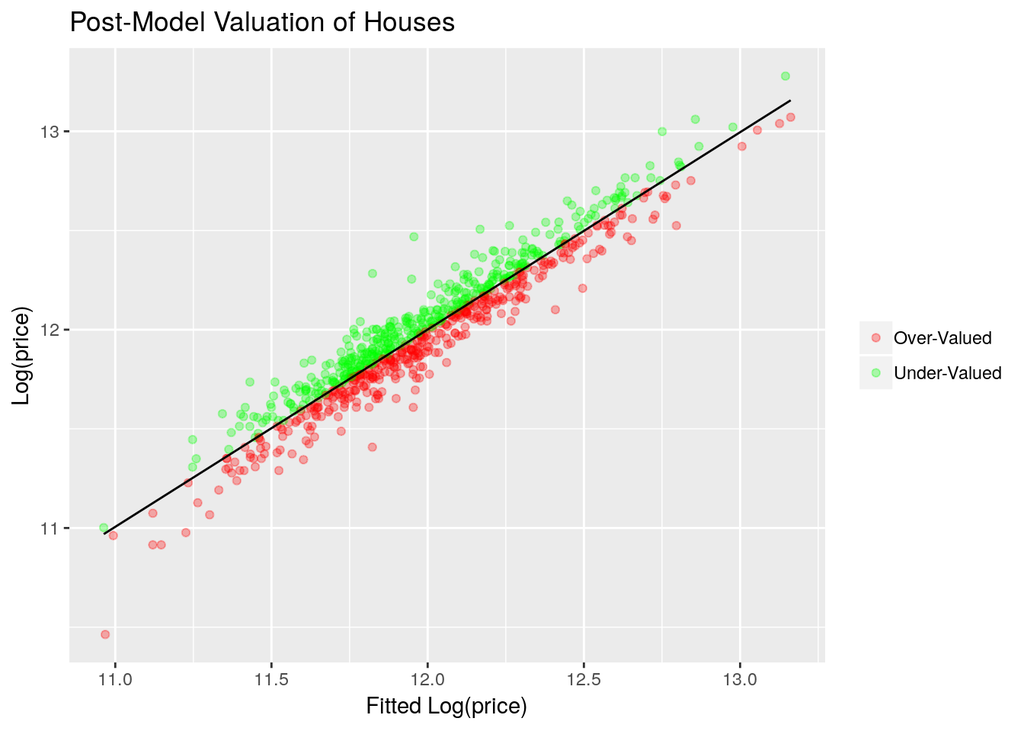

```r
ggplot(ames_validation, aes(x=predicted.log.price, y=log_price, color = valuation)) +
  geom_point(alpha = .3) +
  geom_smooth(method='lm', formula=y~x, se=FALSE, colour="black", size=.5) +
  theme(legend.title=element_blank()) +
  labs(title="Post-Model Valuation of Houses", x="Fitted Log(price)", y= "Log(price)")  +
  scale_color_manual(values = c("Under-Valued" = "green",'Over-Valued' = 'red'))
```

## 2.5 Part 5 Conclusion

A multiple linear regression model was developed to predict the selling price of a given home in Ames, Iowa. 16 out of the original 80 variables were used in the model.

The model is restricted to the houses that:

- were sold under normal conditions
- without pools
- only residential properties
- with the area below 36,000 sq.ft and Lot.Area 215,000 sq.ft.
- price below $615,000

The model archives $R^2$ = 0.92 and RMSE = $18,270 (which is 11% of average price) on out-of-sample data.

The model needs further retraining to include Landmrk Neighboorhood. Further investigation is needed regarding a small but significant number of very large residuals, which may lead to new insights in modeling.

Under-valued houses could be a good investment for real estate firm. The degree of “under-valuing” should be considered because it determines the feasibility of profiting and the profit margin itself.

## 2.6 Appendix

```r
# Exclude some variables
ames_train <- ames_train[,names(ames_train) != "Misc.Feature"]
ames_train <- ames_train[,names(ames_train) != "Misc.Val"]
ames_train <- ames_train[,names(ames_train) != "PID"]
ames_train$Neighborhood <- factor(ames_train$Neighborhood)

# Sale Condition. Exclude unreasonable size per parameter
idx <- which(ames_train$Sale.Condition %in% c("Normal"))
ames_train <- ames_train[idx,]

ames_train <- ames_train %>%
   mutate(
          Lot.Frontage = ifelse(is.na(Lot.Frontage), 0, Lot.Frontage) ,
          Mas.Vnr.Area = ifelse(is.na(Mas.Vnr.Area), 0, Mas.Vnr.Area),
          BsmtFin.Type.1 = ifelse(is.na(BsmtFin.Type.1), 0, BsmtFin.Type.1),
          BsmtFin.SF.1 = ifelse(is.na(BsmtFin.SF.1), 0, BsmtFin.SF.1),
          BsmtFin.Type.2= ifelse(is.na(BsmtFin.Type.2), 0, BsmtFin.Type.2),
          BsmtFin.SF.2 = ifelse(is.na(BsmtFin.SF.2), 0, BsmtFin.SF.2),
          Bsmt.Unf.SF = ifelse(is.na(Bsmt.Unf.SF), 0, Bsmt.Unf.SF),
          Total.Bsmt.SF = ifelse(is.na(Total.Bsmt.SF), 0, Total.Bsmt.SF),
          Bsmt.Full.Bath = ifelse(is.na(Bsmt.Full.Bath), 0, Bsmt.Full.Bath),
          Bsmt.Half.Bath = ifelse(is.na(Bsmt.Half.Bath), 0, Bsmt.Half.Bath),
          Garage.Yr.Blt = ifelse(is.na(Garage.Yr.Blt), 0, Garage.Yr.Blt)
          )

levels <- levels(ames_train$Pool.QC)
levels[length(levels) + 1] <- "NoPool"
ames_train$Pool.QC <- factor(ames_train$Pool.QC, levels = levels)
ames_train$Pool.QC[is.na(ames_train$Pool.QC)] <- "NoPool"

levels <- levels(ames_train$Alley)
levels[length(levels) + 1] <- "NoAccess"
ames_train$Alley <- factor(ames_train$Alley, levels = levels)
ames_train$Alley[is.na(ames_train$Alley)] <- "NoAccess"

levels <- levels(ames_train$Fence)
levels[length(levels) + 1] <- "None"
ames_train$Fence <- factor(ames_train$Fence, levels = levels)
ames_train$Fence[is.na(ames_train$Fence)] <- "None"

levels <- levels(ames_train$Fireplace.Qu)
levels[length(ames_train$Fireplace.Qu) + 1] <- "None"
ames_train$Fireplace.Qu <- factor(ames_train$Fireplace.Qu, levels = levels)
ames_train$Fireplace.Qu[is.na(ames_train$Fireplace.Qu)] <- "None"


## BSMT
levels <- levels(ames_train$Bsmt.Cond)
levels[length(ames_train$Bsmt.Cond) + 1] <- "None"
ames_train$Bsmt.Qual <- factor(ames_train$Bsmt.Qual, levels = levels)
ames_train$Bsmt.Qual[is.na(ames_train$Bsmt.Qual)] <- "None"

levels <- levels(ames_train$Bsmt.Cond)
levels[length(ames_train$Bsmt.Cond) + 1] <- "None"
ames_train$Bsmt.Cond <- factor(ames_train$Bsmt.Cond, levels = levels)
ames_train$Bsmt.Cond[is.na(ames_train$Bsmt.Cond)] <- "None"

levels <- levels(ames_train$Bsmt.Exposure)
levels[length(ames_train$Bsmt.Exposure) + 1] <- "None"
ames_train$Bsmt.Exposure <- factor(ames_train$Bsmt.Exposure, levels = levels)
ames_train$Bsmt.Exposure[is.na(ames_train$Bsmt.Exposure)] <- "None"

levels <- levels(ames_train$BsmtFin.Type.1)
levels[length(ames_train$Bsmt.Exposure) + 1] <- "None"
ames_train$Bsmt.Exposure <- factor(ames_train$Bsmt.Exposure, levels = levels)
ames_train$Bsmt.Exposure[is.na(ames_train$Bsmt.Exposure)] <- "None"


## Garage
# Replacing missing value. Garage year built is replaced with the house year built
idx <- which(ames_train$Garage.Cars > 0 & is.na(ames_train$Garage.Yr.Blt))
ames_train[idx, 'Garage.Yr.Blt'] <- ames_train[idx, 'Year.Built']

levels <- levels(ames_train$Garage.Type)
levels[length(ames_train$Garage.Type) + 1] <- "None"
ames_train$Garage.Type <- factor(ames_train$Garage.Type, levels = levels)
ames_train$Garage.Type[is.na(ames_train$Garage.Type)] <- "None"

levels <- levels(ames_train$Garage.Cond)
levels[length(ames_train$Garage.Cond) + 1] <- "None"
ames_train$Garage.Cond <- factor(ames_train$Garage.Cond, levels = levels)
ames_train$Garage.Cond[is.na(ames_train$Garage.Cond)] <- "None"

levels <- levels(ames_train$Garage.Finish)
levels[length(ames_train$Garage.Finish) + 1] <- "None"
ames_train$Garage.Finish <- factor(ames_train$Garage.Finish, levels = levels)
ames_train$Garage.Finish[is.na(ames_train$Garage.Finish)] <- "None"


ames_train$Garage.Qual <- factor(ames_train$Garage.Qual, levels = levels(ames_train$Garage.Qual)[2:6])
levels <- levels(ames_train$Garage.Qual)
levels[length(ames_train$Garage.Qual) + 1] <- "None"
ames_train$Garage.Qual <- factor(ames_train$Garage.Qual, levels = levels)
ames_train$Garage.Qual[is.na(ames_train$Garage.Qual)] <- "None"


## Ames test
idx <- which(ames_test$Sale.Condition %in% c("Normal"))
ames_test <- ames_test[idx,]



ames_test <- ames_test %>%
  mutate(
    Lot.Frontage = ifelse(is.na(Lot.Frontage), 0, Lot.Frontage) ,
    Mas.Vnr.Area = ifelse(is.na(Mas.Vnr.Area), 0, Mas.Vnr.Area),
    BsmtFin.Type.1 = ifelse(is.na(BsmtFin.Type.1), 0, BsmtFin.Type.1),
    BsmtFin.SF.1 = ifelse(is.na(BsmtFin.SF.1), 0, BsmtFin.SF.1),
    BsmtFin.Type.2= ifelse(is.na(BsmtFin.Type.2), 0, BsmtFin.Type.2),
    BsmtFin.SF.2 = ifelse(is.na(BsmtFin.SF.2), 0, BsmtFin.SF.2),
    Bsmt.Unf.SF = ifelse(is.na(Bsmt.Unf.SF), 0, Bsmt.Unf.SF),
    Total.Bsmt.SF = ifelse(is.na(Total.Bsmt.SF), 0, Total.Bsmt.SF),
    Bsmt.Full.Bath = ifelse(is.na(Bsmt.Full.Bath), 0, Bsmt.Full.Bath),
    Bsmt.Half.Bath = ifelse(is.na(Bsmt.Half.Bath), 0, Bsmt.Half.Bath),
    Garage.Yr.Blt = ifelse(is.na(Garage.Yr.Blt), 0, Garage.Yr.Blt)
  )


levels <- levels(ames_test$Fireplace.Qu)
levels[length(ames_test$Fireplace.Qu) + 1] <- "None"
ames_test$Fireplace.Qu <- factor(ames_test$Fireplace.Qu, levels = levels)
ames_test$Fireplace.Qu[is.na(ames_test$Fireplace.Qu)] <- "None"


## BSMT
levels <- levels(ames_test$Bsmt.Qual)
levels[length(ames_test$Bsmt.Qual) + 1] <- "None"
ames_test$Bsmt.Qual <- factor(ames_test$Bsmt.Qual, levels = levels)
ames_test$Bsmt.Qual[is.na(ames_test$Bsmt.Qual)] <- "None"


levels <- levels(ames_test$Bsmt.Cond)
levels[length(ames_test$Bsmt.Cond) + 1] <- "None"
ames_test$Bsmt.Cond <- factor(ames_test$Bsmt.Cond, levels = levels)
ames_test$Bsmt.Cond[is.na(ames_test$Bsmt.Cond)] <- "None"

levels <- levels(ames_test$Bsmt.Exposure)
levels[length(ames_test$Bsmt.Exposure) + 1] <- "None"
ames_test$Bsmt.Exposure <- factor(ames_test$Bsmt.Exposure, levels = levels)
ames_test$Bsmt.Exposure[is.na(ames_test$Bsmt.Exposure)] <- "None"

levels <- levels(ames_test$BsmtFin.Type.1)
levels[length(ames_test$Bsmt.Exposure) + 1] <- "None"
ames_test$Bsmt.Exposure <- factor(ames_test$Bsmt.Exposure, levels = levels)
ames_test$Bsmt.Exposure[is.na(ames_test$Bsmt.Exposure)] <- "None"


## Garage
# Replacing missing value. Garage year built is replaced with the house year built
idx <- which(ames_test$Garage.Cars > 0 & is.na(ames_test$Garage.Yr.Blt))
ames_test[idx, 'Garage.Yr.Blt'] <- ames_test[idx, 'Year.Built']

levels <- levels(ames_test$Garage.Type)
levels[length(ames_test$Garage.Type) + 1] <- "None"
ames_test$Garage.Type <- factor(ames_test$Garage.Type, levels = levels)
ames_test$Garage.Type[is.na(ames_test$Garage.Type)] <- "None"

levels <- levels(ames_test$Garage.Cond)
levels[length(ames_test$Garage.Cond) + 1] <- "None"
ames_test$Garage.Cond <- factor(ames_test$Garage.Cond, levels = levels)
ames_test$Garage.Cond[is.na(ames_test$Garage.Cond)] <- "None"

levels <- levels(ames_test$Garage.Finish)
levels[length(ames_test$Garage.Finish) + 1] <- "None"
ames_test$Garage.Finish <- factor(ames_test$Garage.Finish, levels = levels)
ames_test$Garage.Finish[is.na(ames_test$Garage.Finish)] <- "None"

levels <- levels(ames_test$Garage.Qual)
levels[length(ames_test$Garage.Qual) + 1] <- "None"
ames_test$Garage.Qual <- factor(ames_test$Garage.Qual, levels = levels)
ames_test$Garage.Qual[is.na(ames_test$Garage.Qual)] <- "None"

levels <- levels(ames_test$Neighborhood)
ames_test$Neighborhood <- factor(ames_test$Neighborhood, levels = levels)


## Ames validation
ames_validation$Neighborhood <- factor(ames_validation$Neighborhood)

# Sale Condition. Exclude unreasonable size per parameter
idx <- which(ames_validation$Sale.Condition %in% c("Normal"))
ames_validation <- ames_validation[idx,]

ames_validation <- ames_validation %>%
   mutate(
          Lot.Frontage = ifelse(is.na(Lot.Frontage), 0, Lot.Frontage) ,
          Mas.Vnr.Area = ifelse(is.na(Mas.Vnr.Area), 0, Mas.Vnr.Area),
          BsmtFin.Type.1 = ifelse(is.na(BsmtFin.Type.1), 0, BsmtFin.Type.1),
          BsmtFin.SF.1 = ifelse(is.na(BsmtFin.SF.1), 0, BsmtFin.SF.1),
          BsmtFin.Type.2= ifelse(is.na(BsmtFin.Type.2), 0, BsmtFin.Type.2),
          BsmtFin.SF.2 = ifelse(is.na(BsmtFin.SF.2), 0, BsmtFin.SF.2),
          Bsmt.Unf.SF = ifelse(is.na(Bsmt.Unf.SF), 0, Bsmt.Unf.SF),
          Total.Bsmt.SF = ifelse(is.na(Total.Bsmt.SF), 0, Total.Bsmt.SF),
          Bsmt.Full.Bath = ifelse(is.na(Bsmt.Full.Bath), 0, Bsmt.Full.Bath),
          Bsmt.Half.Bath = ifelse(is.na(Bsmt.Half.Bath), 0, Bsmt.Half.Bath),
          Garage.Yr.Blt = ifelse(is.na(Garage.Yr.Blt), 0, Garage.Yr.Blt)
          )


levels <- levels(ames_validation$Fireplace.Qu)
levels[length(ames_validation$Fireplace.Qu) + 1] <- "None"
ames_validation$Fireplace.Qu <- factor(ames_validation$Fireplace.Qu, levels = levels)
ames_validation$Fireplace.Qu[is.na(ames_validation$Fireplace.Qu)] <- "None"


## BSMT
levels <- levels(ames_validation$Bsmt.Qual)
levels[length(ames_validation$Bsmt.Qual) + 1] <- "None"
ames_validation$Bsmt.Qual <- factor(ames_validation$Bsmt.Qual, levels = levels)
ames_validation$Bsmt.Qual[is.na(ames_validation$Bsmt.Qual)] <- "None"


levels <- levels(ames_validation$Bsmt.Cond)
levels[length(ames_validation$Bsmt.Cond) + 1] <- "None"
ames_validation$Bsmt.Cond <- factor(ames_validation$Bsmt.Cond, levels = levels)
ames_validation$Bsmt.Cond[is.na(ames_validation$Bsmt.Cond)] <- "None"

levels <- levels(ames_validation$Bsmt.Exposure)
levels[length(ames_validation$Bsmt.Exposure) + 1] <- "None"
ames_validation$Bsmt.Exposure <- factor(ames_validation$Bsmt.Exposure, levels = levels)
ames_validation$Bsmt.Exposure[is.na(ames_validation$Bsmt.Exposure)] <- "None"

levels <- levels(ames_validation$BsmtFin.Type.1)
levels[length(ames_validation$Bsmt.Exposure) + 1] <- "None"
ames_validation$Bsmt.Exposure <- factor(ames_validation$Bsmt.Exposure, levels = levels)
ames_validation$Bsmt.Exposure[is.na(ames_validation$Bsmt.Exposure)] <- "None"


## Garage
# Replacing missing value. Garage year built is replaced with the house year built
idx <- which(ames_validation$Garage.Cars > 0 & is.na(ames_validation$Garage.Yr.Blt))
ames_validation[idx, 'Garage.Yr.Blt'] <- ames_validation[idx, 'Year.Built']

levels <- levels(ames_validation$Garage.Type)
levels[length(ames_validation$Garage.Type) + 1] <- "None"
ames_validation$Garage.Type <- factor(ames_validation$Garage.Type, levels = levels)
ames_validation$Garage.Type[is.na(ames_validation$Garage.Type)] <- "None"

levels <- levels(ames_validation$Garage.Cond)
levels[length(ames_validation$Garage.Cond) + 1] <- "None"
ames_validation$Garage.Cond <- factor(ames_validation$Garage.Cond, levels = levels)
ames_validation$Garage.Cond[is.na(ames_validation$Garage.Cond)] <- "None"

levels <- levels(ames_validation$Garage.Finish)
levels[length(ames_validation$Garage.Finish) + 1] <- "None"
ames_validation$Garage.Finish <- factor(ames_validation$Garage.Finish, levels = levels)
ames_validation$Garage.Finish[is.na(ames_validation$Garage.Finish)] <- "None"

levels <- levels(ames_validation$Garage.Qual)
levels[length(ames_validation$Garage.Qual) + 1] <- "None"
ames_validation$Garage.Qual <- factor(ames_validation$Garage.Qual, levels = levels)
ames_validation$Garage.Qual[is.na(ames_validation$Garage.Qual)] <- "None"

levels <- levels(ames_validation$Neighborhood)
ames_validation$Neighborhood <- factor(ames_validation$Neighborhood, levels = levels)
```